# 7.9 Exercises

# Exercise 6

In this exercise, you will further analyze the **Wage** data set considered throughout this chapter.

```r
# Wage data is in the ISLR library
library(ISLR)
```

1. Perform polynomial regression to predict **wage** using **age**. Use cross-validation to select the optimal degree *d* for the polynomial. What degree was chose, and how does this compare to the results of hypothesis testing using ANOVA? Make a plot of the resulting polynomial fit to the data.

```r
# Set seed for repeatability
set.seed(1)

# glm() and cv.glm() for cross-validation are in das boot
library(boot)

# Explore up to the 10th degree polynomial
maxDegree = 10
# Use 10-fold cross-validation
K = 10

# Find the 10-fold cross-validation estimate for the test MSE for each polynomial model
cv.error = rep(0, maxDegree)
for (d in 1:maxDegree){
  glm.fit = glm(wage ~ poly(age, d), data = Wage)
  cv.error[d] = cv.glm(data = Wage, glmfit = glm.fit, K = K)$delta[1]
}

# Find the degree model which yields the lowest estimated test MSE
bestDegree = which.min(cv.error)
bestDegree
```

```
## [1] 4
```

*According to our cross-validation, a quartic model should yield the best results for predicting* **wage** *via* **age**.

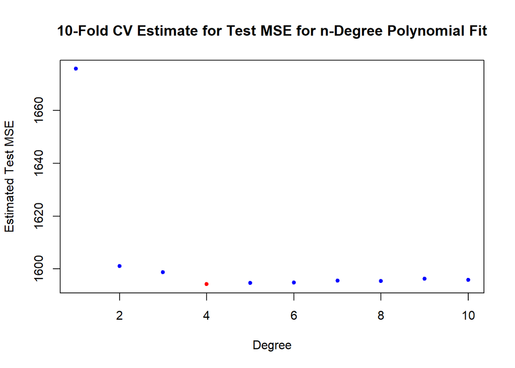

```r
plot(cv.error, xlab = 'Degree', ylab = 'Estimated Test MSE', main = '10-Fold CV Estimate for Test MSE for n-Degree Polynomial Fit', pch = 20, col = 'blue')
points(bestDegree, cv.error[bestDegree], col = 'red', pch = 20)
```

*You can see that a higher degree model tends to yield a similar test MSE, but the quartic model has the lowest estimated test MSE and is easier to interpret than a higher degree model. It also has a lower variance.*

```r
# Use ANOVA to determine the best polynomial fit (up to 10)
for (d in 2:maxDegree) {
  print(paste('d = ', d))
  print(anova(lm(wage ~ poly(age, d - 1), data = Wage), lm(wage ~ poly(age, d), data = Wage)))
}
```

```
## [1] "d =  2"
## Analysis of Variance Table
##
## Model 1: wage ~ poly(age, d - 1)
## Model 2: wage ~ poly(age, d)
##   Res.Df     RSS Df Sum of Sq      F    Pr(>F)
## 1   2998 5022216
## 2   2997 4793430  1    228786 143.04 < 2.2e-16 ***
## ---
## Signif. codes:  0 '***' 0.001 '**' 0.01 '*' 0.05 '.' 0.1 ' ' 1
## [1] "d =  3"
## Analysis of Variance Table
##
## Model 1: wage ~ poly(age, d - 1)
## Model 2: wage ~ poly(age, d)
##   Res.Df     RSS Df Sum of Sq      F   Pr(>F)
## 1   2997 4793430
## 2   2996 4777674  1     15756 9.8801 0.001687 **
## ---
## Signif. codes:  0 '***' 0.001 '**' 0.01 '*' 0.05 '.' 0.1 ' ' 1
## [1] "d =  4"
## Analysis of Variance Table
##
## Model 1: wage ~ poly(age, d - 1)
## Model 2: wage ~ poly(age, d)
##   Res.Df     RSS Df Sum of Sq      F  Pr(>F)
## 1   2996 4777674
## 2   2995 4771604  1    6070.2 3.8101 0.05104 .
## ---
## Signif. codes:  0 '***' 0.001 '**' 0.01 '*' 0.05 '.' 0.1 ' ' 1
## [1] "d =  5"
## Analysis of Variance Table
##
## Model 1: wage ~ poly(age, d - 1)
## Model 2: wage ~ poly(age, d)
##   Res.Df     RSS Df Sum of Sq     F Pr(>F)
## 1   2995 4771604
## 2   2994 4770322  1    1282.6 0.805 0.3697
## [1] "d =  6"
## Analysis of Variance Table
```

[output cut: 25 more lines]

```
## Model 1: wage ~ poly(age, d - 1)
## Model 2: wage ~ poly(age, d)
##   Res.Df     RSS Df Sum of Sq      F  Pr(>F)
## 1   2991 4763707
## 2   2990 4756703  1    7004.3 4.4028 0.03596 *
## ---
## Signif. codes:  0 '***' 0.001 '**' 0.01 '*' 0.05 '.' 0.1 ' ' 1
## [1] "d =  10"
## Analysis of Variance Table
##
## Model 1: wage ~ poly(age, d - 1)
## Model 2: wage ~ poly(age, d)
##   Res.Df     RSS Df Sum of Sq      F Pr(>F)
## 1   2990 4756703
## 2   2989 4756701  1    2.6375 0.0017 0.9675
```

*The ANOVA analysis suggests that a cubic model should be sufficient.*

```r
cv.fit = lm(wage ~ poly(age, bestDegree), data = Wage)
anova.fit = lm(wage ~ poly(age, 3), data = Wage)

# Look at the estimated coefficients for the model yielded by CV
cv.fit
```

```
##
## Call:
## lm(formula = wage ~ poly(age, bestDegree), data = Wage)
##
## Coefficients:
##            (Intercept)  poly(age, bestDegree)1  poly(age, bestDegree)2
##                 111.70                  447.07                 -478.32
## poly(age, bestDegree)3  poly(age, bestDegree)4
##                 125.52                  -77.91
```

```r
anova.fit
```

```
##
## Call:
## lm(formula = wage ~ poly(age, 3), data = Wage)
##
## Coefficients:
##   (Intercept)  poly(age, 3)1  poly(age, 3)2  poly(age, 3)3
##         111.7          447.1         -478.3          125.5
```

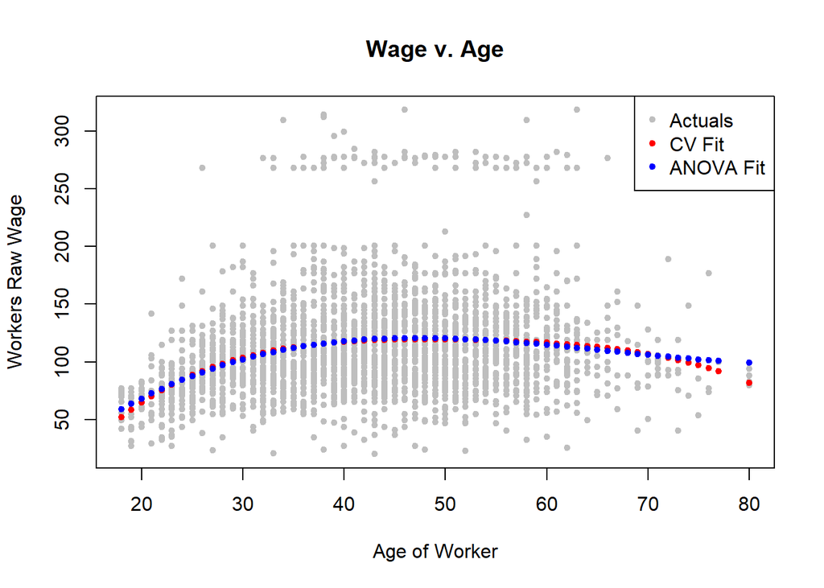

```r
# Plot the estimated models v. the actual values
plot(Wage$age, Wage$wage, xlab = 'Age of Worker', ylab = 'Workers Raw Wage', main = 'Wage v. Age', col = 'grey', pch = 20)
points(Wage$age, cv.fit$fitted.values, col = 'red', pch = 20)
points(Wage$age, anova.fit$fitted.values, col = 'blue', pch = 20)
legend('topright', legend = c('Actuals', 'CV Fit', 'ANOVA Fit'), col = c('grey', 'red', 'blue'), pch = 20)
```

*On the range of* **age** *in the training data, the cubic and quartic models have very similar predictions. We can see that the quartic fit, which was suggested by cross-validation, tends to experience a bit more variability at the edges of the ranges. With that in mind, I would suggest the cubic model, which was suggested by the ANOVA, as the better model. It will be more stable and is a simpler model, which should be preferred if the predictive performance is similar.*

2. Fit a step function to predict **wage** using **age**, and perform cross-validation to choose the optimal number of cuts. Make a plot of the fit obtained.

```r
# Look at 2 cuts to 10 cuts to see which performs best (1 cut is just an intercept-only model)
maxCuts = 10

# Use 10-fold CV for comparison
K = 10
set.seed(1)
cv.error = rep(0, maxCuts - 1)
for (numCuts in 2:maxCuts) {
  Wage$ageCuts = cut(Wage$age, numCuts)
  glm.fit = glm(wage ~ ageCuts, data = Wage)
  cv.error[numCuts - 1] = cv.glm(Wage, glm.fit, K = K)$delta[1]
}

bestCuts = which.min(cv.error) + 1
bestCuts
```

```
## [1] 8
```

*The cross-validation suggests that 8 cuts yields the best step function model.*

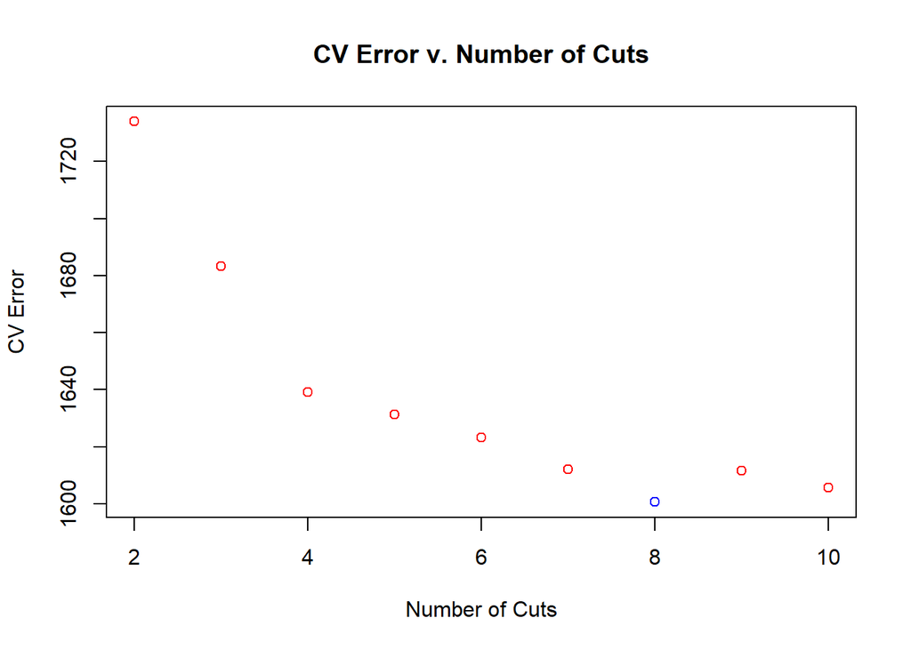

```r
plot(2:maxCuts, cv.error, xlab = 'Number of Cuts', ylab = 'CV Error', main = 'CV Error v. Number of Cuts', col = 'red')
points(bestCuts, cv.error[bestCuts - 1], col = 'blue')
```

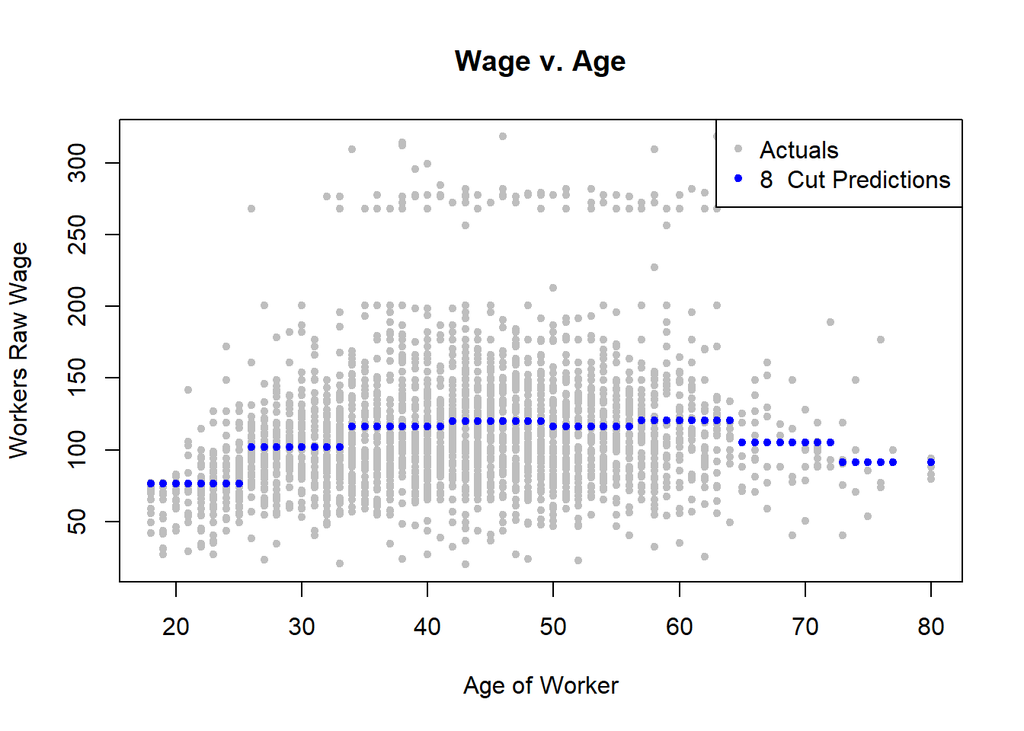

```r
cuts.fit = lm(wage ~ cut(age, bestCuts), data = Wage)
plot(Wage$age, Wage$wage, xlab = 'Age of Worker', ylab = 'Workers Raw Wage', main = 'Wage v. Age', col = 'grey', pch = 20)
points(Wage$age, cuts.fit$fitted.values, col = 'blue', pch = 20)
legend('topright', legend = c('Actuals', paste(bestCuts, ' Cut Predictions')), col = c('grey', 'blue'), pch = 20)
```

*And here we have our estimated model with 8 cuts, looking nice and pretty. Notice that the middle 4 cuts have very little deviation. We could probably switch to a model with fewer cuts if we did not place our cuts uniformly.*

# Exercise 7

The **Wage** data set contains a number of other features not explored in this chapter, such as marital status (**maritl**), job class (**jobclass**), and others. Explore the relationships between some of these other predictors and **wage**, and use non-linear fitting techniques in order to fit flexible models to the data. Create plots of the results obtained and write a summary of your findings.

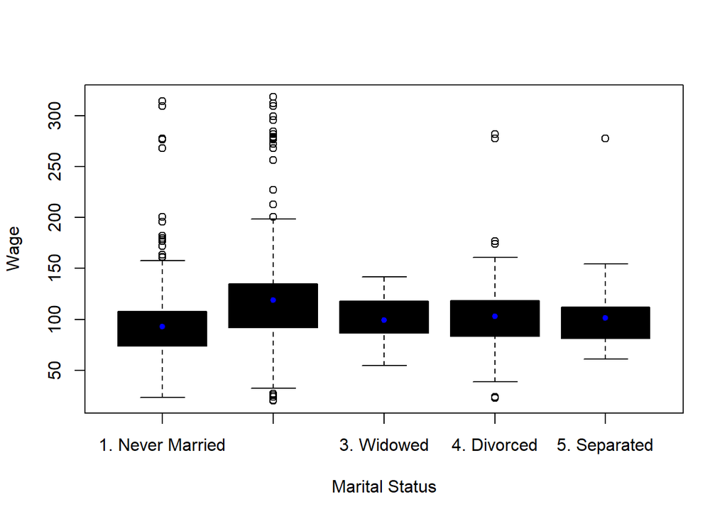

```r
# First, we'll look at predicting wage via marital status
# For a single qualitative predictor, an lm() fit is already a step function
step.fit = lm(wage ~ maritl, data = Wage)
plot(Wage$maritl, Wage$wage, col = 'black', xlab = 'Marital Status', ylab = 'Wage')
points(Wage$maritl, step.fit$fitted.values, col = 'blue', pch = 20)
```

*If we use all of the training data and only the Marital Status as a predictor, then of course the resulting step fit simply predicts the mean value of the training data at that level of marital status.*

```r
mean((Wage$wage - step.fit$fitted.values)^2)
```

```
## [1] 1619.647
```

*This simple model is very easy to interpet. It also yields an MSE of 1619.647. Let’s see how that compares to some other models.*

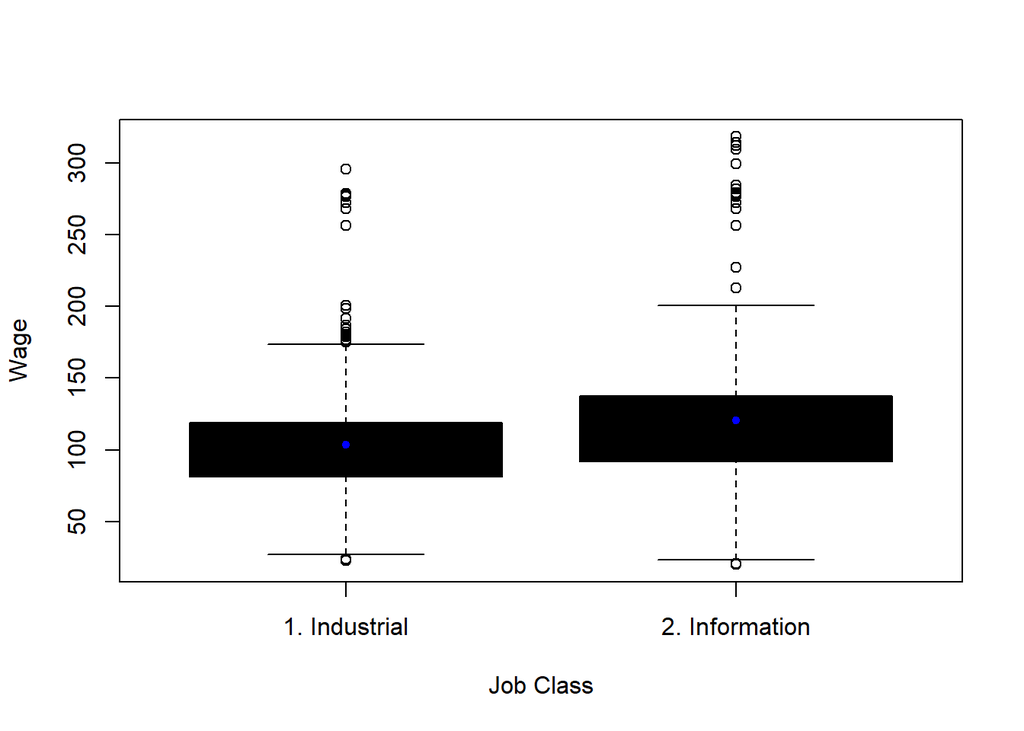

```r
# Let's look at predicting wage via job class
# Since job class is also a qualitative predictor, we will look at the same simple step model
step.fit = lm(wage ~ jobclass, data = Wage)
plot(Wage$jobclass, Wage$wage, col = 'black', xlab = 'Job Class', ylab = 'Wage')
points(Wage$jobclass, step.fit$fitted.values, col = 'blue', pch = 20)
```

```r
mean((Wage$wage - step.fit$fitted.values)^2)
```

```
## [1] 1666.182
```

*This model, using an essentially binary fit to predict wage, is even more simple than the step function using marital status. It also has a slightly higher MSE at 1666.182.*

```r
# Now let's look at what happens when we use a step model with both predictors
step.fit = lm(wage ~ maritl + jobclass, data = Wage)
summary(step.fit)
```

```
##
## Call:
## lm(formula = wage ~ maritl + jobclass, data = Wage)
##
## Residuals:
##      Min       1Q   Median       3Q      Max
## -107.108  -22.689   -5.749   16.445  212.492
##
## Coefficients:
##                        Estimate Std. Error t value Pr(>|t|)
## (Intercept)              85.315      1.679  50.818  < 2e-16 ***
## maritl2. Married         25.356      1.776  14.279  < 2e-16 ***
## maritl3. Widowed          8.137      9.178   0.887  0.37541
## maritl4. Divorced         9.664      3.166   3.052  0.00229 **
## maritl5. Separated        7.189      5.539   1.298  0.19441
## jobclass2. Information   16.523      1.442  11.460  < 2e-16 ***
## ---
## Signif. codes:  0 '***' 0.001 '**' 0.01 '*' 0.05 '.' 0.1 ' ' 1
##
## Residual standard error: 39.43 on 2994 degrees of freedom
## Multiple R-squared:  0.1086, Adjusted R-squared:  0.1072
## F-statistic: 72.98 on 5 and 2994 DF,  p-value: < 2.2e-16
```

```r
mean((Wage$wage - step.fit$fitted.values)^2)
```

```
## [1] 1551.584
```

*Using what is now essentially a step model with 10 different sections, we have a lower MSE at 1551.584. We would of course expect our MSE to decrease as we increase the model flexibility since we have only looked at training MSE thusfar.*

*Let’s compare this 2-predictor step model with our step model using 8 cuts with the age predictor. We’ll just do a quick comparison by splitting the data in half. We will fit both models with one half and compare their test MSEs from the other half.*

```r
set.seed(1)
train = sample(nrow(Wage), nrow(Wage)/2)
fit1 = lm(wage ~ cut(age, 8), data = Wage, subset = train)
fit2 = lm(wage ~ maritl + jobclass, data = Wage, subset = train)
getMSE = function(fit, newdata){
  pred = predict(fit, newdata)
  return(mean((fit$model$wage - pred)^2))
}
getMSE(fit1, Wage[-train,])
```

```
## [1] 1942.949
```

```r
getMSE(fit2, Wage[-train,])
```

```
## [1] 1975.714
```

*Based on this quick test, we can see some evidence that the old 8-cut step model using only the age predictor may be better at predicting wage than this new model using both marital status and job class predictors.*